# Connecticut Lake Profile Data

[figure not shown]

# Quonnipaug Lake Report

**Quonnipaug Lake** is a **96.1 acre** lake, located in the town of **Guilford** within **New Haven County**, Connecticut. The max measured depth of this lake is **14.6 meters**. It has been sampled by [CT DEEP Water Monitoring and Assessment](https://portal.ct.gov/deep/water/inland-water-monitoring/lake-water-quality-monitoring) on **2** sampling day(s) between **2018-04-10** and **2018-08-21**.

The DEEP Water Monitoring Program conducts ambient monitoring and the [related assessments of the State’s waters](https://portal.ct.gov/deep/water/water-quality/water-quality-305b-report-to-congress), including Connecticut’s many lakes and ponds. In Connecticut, there are a total of 2,267 lakes and ponds greater than 10 acres in size.

The Monitoring Program conducts annual monitoring on approximately 10-20 of these lakes and ponds per year. The type and locations of monitoring during a given year is determined by a variety of factors, including participation in regional and national studies, as well as support requests from groups within DEEP.

## Monitoring Location(s)

[interactive chart not shown]

## Results

The below results are first grouped according to the monitoring location, and then according to the date they were sampled. Click [here](https://www.waterqualitydata.us/data/Result/search?organization=CT_DEP01_WQX&project=lakesABM&project=lakesNLA&siteid=19356&mimeType=csv&zip=no&dataProfile=resultPhysChem&providers=NWIS&providers=STORET) to download the water chemistry profile data associated with these monitoring location(s).

### Station 19356

#### 2018-04-10

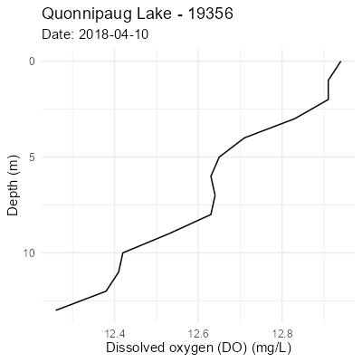

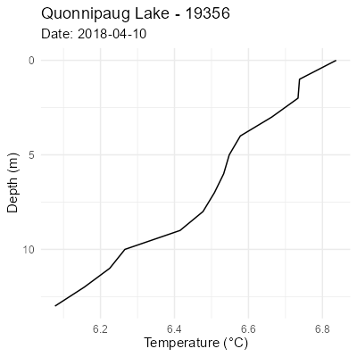

#### 2018-08-21

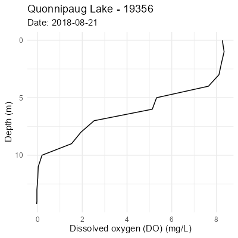

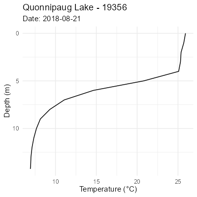